# HelloFresh Recipe Score Prediction -Krishna Punyakoti

As **HelloFresh** create new recipes, it is essential to know how they will perform. A recipe score or rating is the comparative ranking that a user gives to a specific recipe. If customers like a specific recipe, it can be expected that they rate the recipe high, if the customer did not like a recipe, then they might rate it low.  
Aim of this assignment is to **build a model** that predicts the average recipe score of new recipes based on the available data.

### In this document, I will walk you through my approach and strategy towards training a model to predict the recipe scores more accurately with better intrepretability.

### Contents:

Pre-Work

### Part I: Data Gathering

Load Data  
Validate Data

### Part II: Data Preprocessing

Nulls & Duplicates  
Feature Extraction  
Merge Tables  
Split Data

### Part III: Exploratory Data Anlaysis

Dependent Variable  
Predictor Variables' Analysis  
Find Insignificant Variables Using StatsModel

### Part IV: Machine Learning

Baseline Models  
Model Optimization  
Predictions on Validation Set  
Final Model Selection  
Test Set Predictions  
Productionzing Model

## Pre-work - Import Essential Libraries

```python
#basic essential libraries
import pandas as pd
import numpy as np
import sklearn as sk
from scipy.stats import norm
import mysql.connector
#common model algorithms
from sklearn.ensemble import RandomForestRegressor, GradientBoostingRegressor
from xgboost import XGBRegressor
from sklearn.linear_model import LinearRegression, RidgeCV
#statsmodel
import statsmodels.api as sm
from scipy import stats
#evaluation metrics and tuning models
from sklearn.model_selection import train_test_split, GridSearchCV, cross_val_score, KFold
from sklearn.metrics import mean_squared_error, r2_score
#to ignore warning messages
import warnings
warnings.filterwarnings('ignore')
from subprocess import check_output
```

```python
#Data visualization
import matplotlib as mpl
import matplotlib.pyplot as plt
import matplotlib.pylab as pylab
import seaborn as sns
#set visual parameters
%matplotlib inline
mpl.style.use('ggplot')
sns.set()
pylab.rcParams['figure.figsize'] = 8,5
```

# Part I DATA GATHERING

## 1. Load Data

**I have created a schema, *hellofresh*, in localhost mysql server. We will use this database to retrive the required data.**

```python
#create connection to connect to the mysql server and hellofresh database
connection = mysql.connector.connect(host = 'localhost', user='root', password='root', db= 'hellofresh')
```

```python
#retrieve recipe_ratings and ingredients data from the tables
recipe_ratings = pd.read_sql_query('select * from recipe_ratings', connection)
recipe_ingredients = pd.read_sql_query('select * from ingredients', connection)
```

recipe_ratings['price'] = recipe_ratings['price'].map(lambda x: x.rstrip('\r')).astype(float) recipe_ratings['score'] = recipe_ratings['score'].astype(float) recipe_ingredients['Unit_weight_amount'] = recipe_ingredients['Unit_weight_amount'].astype(float)

```python
ratings = recipe_ratings.copy()
ingredients = recipe_ingredients.copy()
```

```python
print(ratings.shape)
print(ingredients.shape)
```

```
(222, 4)
(2074, 4)
```

## 2. Validate DataSets

```python
ratings.info()
```

```
<class 'pandas.core.frame.DataFrame'>
RangeIndex: 222 entries, 0 to 221
Data columns (total 4 columns):
recipe_code    222 non-null object
score          179 non-null float64
new            222 non-null int64
price          222 non-null float64
dtypes: float64(2), int64(1), object(1)
memory usage: 7.0+ KB
```

```python
ingredients.info()
```

```
<class 'pandas.core.frame.DataFrame'>
RangeIndex: 2074 entries, 0 to 2073
Data columns (total 4 columns):
recipe_code           2074 non-null object
Recipe_name           2074 non-null object
Ingredient            2074 non-null object
Unit_weight_amount    2074 non-null float64
dtypes: float64(1), object(3)
memory usage: 64.9+ KB
```

# Part II DATA PREPROCESSING

## 1. Nulls and Duplicates

The datasets look clean without many nulls.  
We have **NULLS** in score column. This is not any data-related issue or missing values. This is obvious as we know that these are the entries for which we need to predict scores. Hence we can fill them with **zeros** for now.

```python
ratings.score.fillna(0,inplace=True)
```

```python
ingredients.duplicated().value_counts()
```

```
False    1959
True      115
dtype: int64
```

We have **duplicate rows** in the ingredients dataset. This however, was identified on **thrid iteration** of modeling. Hence dropping them upfront.

```python
ingredients.drop_duplicates(inplace=True)
```

## 2. Feature Extraction

Before joining *ingredients* and *ratings* tables, we have to extract certain meaningful columns that we can use as part of modeling.

1. Obviously, we do not want to pivot all unique *Ingredients* as that would make the feature space more than the number of records. Its not that we cannot but given data, it is better to proceed with other sort of feature.
2. We can extract *number of ingredients* used per recipe as one feature.
3. Since our *Unit_weight_amount* values are already scaled, we can conviniently sum them up to get a *total ingredients weight* per recipe.
4. We can also try extracting the *number of words in the recipe name* to see if this has any impact on the score. Otherwise, we do not need *Recipe_name* column

### *Ingredient Count*

```python
ingredient_count = pd.DataFrame(ingredients.recipe_code.value_counts())
ingredient_count.reset_index(inplace=True)
ingredient_count.columns = ['recipe_code', 'ing_count']

ingredients = pd.merge(ingredients, ingredient_count, on = 'recipe_code')
ingredients.head(3)
```

|  | recipe_code | Recipe_name | Ingredient | Unit_weight_amount | ing_count |
| --- | --- | --- | --- | --- | --- |
| 0 | R10030 | Teriyaki Chicken with Coconut Rice and Bok Choy | Chicken, Breasts | 12.00 | 7 |
| 1 | R10030 | Teriyaki Chicken with Coconut Rice and Bok Choy | Rice, Basmati | 0.75 | 7 |
| 2 | R10030 | Teriyaki Chicken with Coconut Rice and Bok Choy | Garlic, Peeled | 2.00 | 7 |

### *recipe_word_count*

```python
def main_ing(dataset):
    rc = pd.DataFrame(dataset['Recipe_name'].str.count(' '))
    rc.columns = ['recipe_word_count']
    rc = rc+1
    return rc

ingredients = ingredients.join(main_ing(ingredients))
ingredients.head(3)
```

|  | recipe_code | Recipe_name | Ingredient | Unit_weight_amount | ing_count | recipe_word_count |
| --- | --- | --- | --- | --- | --- | --- |
| 0 | R10030 | Teriyaki Chicken with Coconut Rice and Bok Choy | Chicken, Breasts | 12.00 | 7 | 8 |
| 1 | R10030 | Teriyaki Chicken with Coconut Rice and Bok Choy | Rice, Basmati | 0.75 | 7 | 8 |
| 2 | R10030 | Teriyaki Chicken with Coconut Rice and Bok Choy | Garlic, Peeled | 2.00 | 7 | 8 |

### *total unit weight*

```python
ing_wt = pd.DataFrame(ingredients.groupby('recipe_code')['Unit_weight_amount'].sum())
ing_wt.reset_index(inplace=True)
ing_wt.columns = ['recipe_code', 'ing_weight']

ingredients = pd.merge(ingredients, ing_wt, on = 'recipe_code', how='outer')
ingredients.head(3)
```

|  | recipe_code | Recipe_name | Ingredient | Unit_weight_amount | ing_count | recipe_word_count | ing_weight |
| --- | --- | --- | --- | --- | --- | --- | --- |
| 0 | R10030 | Teriyaki Chicken with Coconut Rice and Bok Choy | Chicken, Breasts | 12.00 | 7 | 8 | 31.25 |
| 1 | R10030 | Teriyaki Chicken with Coconut Rice and Bok Choy | Rice, Basmati | 0.75 | 7 | 8 | 31.25 |
| 2 | R10030 | Teriyaki Chicken with Coconut Rice and Bok Choy | Garlic, Peeled | 2.00 | 7 | 8 | 31.25 |

### drop proxy columns in ingredients table

```python
drop_cols = ['Ingredient','Unit_weight_amount','Recipe_name']
for x in drop_cols:
    ingredients.drop(x, axis=1, inplace=True)
```

## 3. Merge tables

```python
hello_fresh = pd.merge(ratings, ingredients, on = 'recipe_code')
hello_fresh.head(3)
```

|  | recipe_code | score | new | price | ing_count | recipe_word_count | ing_weight |
| --- | --- | --- | --- | --- | --- | --- | --- |
| 0 | R10082 | 4.94 | 0 | 8.1 | 8 | 3 | 62.5 |
| 1 | R10082 | 4.94 | 0 | 8.1 | 8 | 3 | 62.5 |
| 2 | R10082 | 4.94 | 0 | 8.1 | 8 | 3 | 62.5 |

```python
#drop the duplicates
hello_fresh.drop_duplicates(inplace=True)
hello_fresh.head(3)
```

|  | recipe_code | score | new | price | ing_count | recipe_word_count | ing_weight |
| --- | --- | --- | --- | --- | --- | --- | --- |
| 0 | R10082 | 4.94 | 0 | 8.10 | 8 | 3 | 62.50 |
| 8 | R10118 | 4.96 | 0 | 7.80 | 8 | 8 | 58.25 |
| 16 | R10123B | 2.11 | 0 | 7.73 | 9 | 10 | 24.00 |

### Prepare train & test sets based on the *'new'* indicator.

#### Test set is the set for which we need to make predictions.

```python
train = hello_fresh[hello_fresh['new']==0]
test = hello_fresh[hello_fresh['new']==1]
```

### Drop Obvisouly insignifical columns

```python
#drop 'new' indicator
train.drop('new', axis=1, inplace=True)
test.drop('new', axis=1, inplace=True)

#id column
test_recipes = test['recipe_code'] #save test_recipe codes.
train.drop('recipe_code', axis=1, inplace=True)
test.drop('recipe_code', axis=1, inplace=True)

#target column
y_train = train['score']
train.drop('score', axis =1, inplace = True)
test.drop('score', axis=1, inplace=True)
```

```python
print(train.shape)
print(test.shape)
```

```
(178, 4)
(43, 4)
```

```python
#export test set
PATH = "C:/Users/kpunyakoti/Desktop/Future/HelloFresh/"
test_set = test.copy()
test_set['recipe_code'] = test_recipes
test_set.to_csv(f'{PATH}test_set.csv')
```

## 4. Split Data

As we have the train set ready, we can now split it in to **train** and **validation** sets.

```python
train_x, val_x, train_y, val_y = train_test_split(train, y_train, test_size = 0.2, random_state = 17)
```

Go to Top

# Part III Exploratory Data Analysis

### on "TRAIN SET" ONLY

```python
#score distribution
df_eda = train_x.copy()
target = train_y.copy()
```

### 1. Dependent Variable distribution

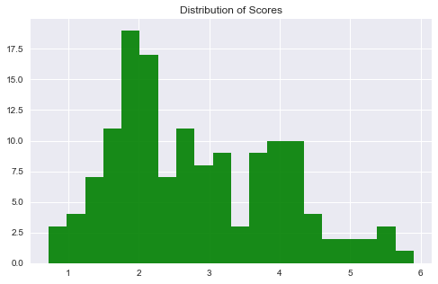

```python
#distribution of scores
title_font = { 'weight' : 'bold','size':'16'}
plt.title('Distribution of Scores')
plt.hist(target, alpha=0.9, bins=20, color = 'green')
plt.show()
```

```
 mu = 0.95 and sigma = 0.43
```

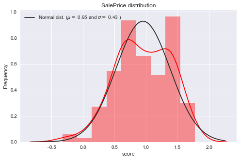

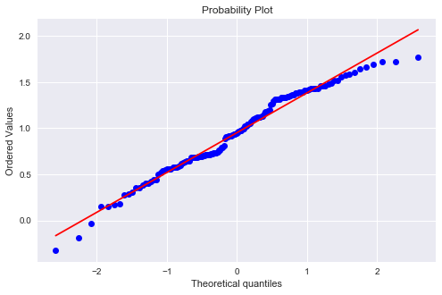

```python
sns.distplot(np.log(target), fit=norm, color = 'red');

# Get the fitted parameters used by the function
(mu, sigma) = norm.fit(np.log(target))
print( '\n mu = {:.2f} and sigma = {:.2f}\n'.format(mu, sigma))

#Now plot the distribution
plt.legend(['Normal dist. ($\mu=$ {:.2f} and $\sigma=$ {:.2f} )'.format(mu, sigma)],
            loc='best')
plt.ylabel('Frequency')
plt.title('SalePrice distribution')

#Get also the QQ-plot
fig = plt.figure()
res = stats.probplot(np.log(target), plot=plt)
plt.show()
```

### 2. Predictor variables' analysis

#### check correlation between independent variables to the dependent variable

```python
df_corr = train_x.copy()
df_corr['score'] = train_y
```

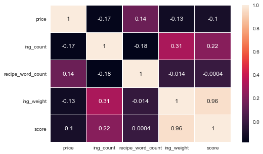

```python
corr = df_corr.corr()
sns.heatmap(corr, annot=True, linewidths = 0.1, linecolor = 'white')
```

### generate Pairplots to check the relationship

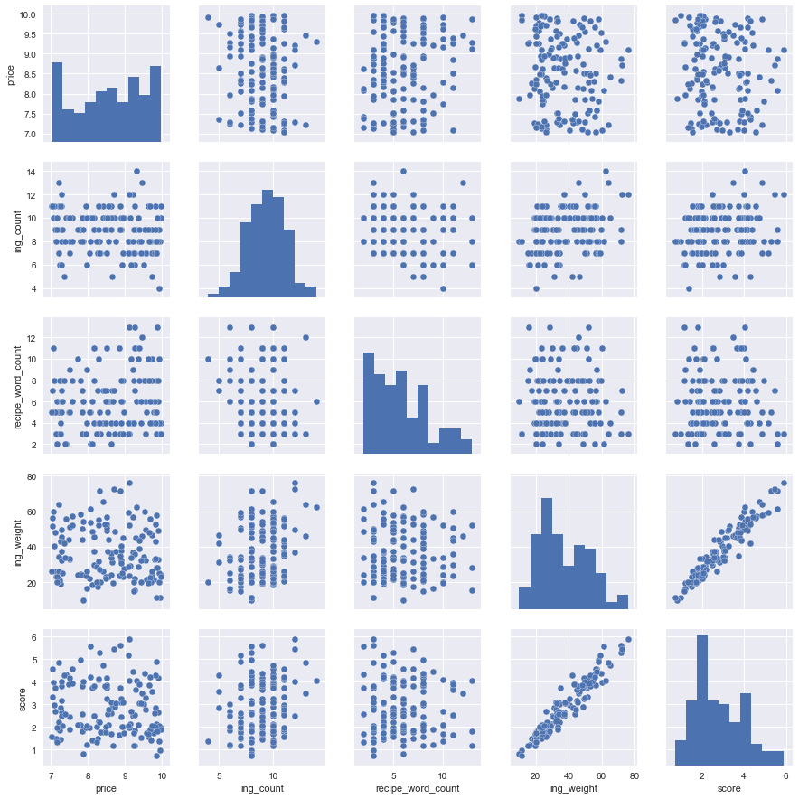

```python
sns.pairplot(df_corr)
```

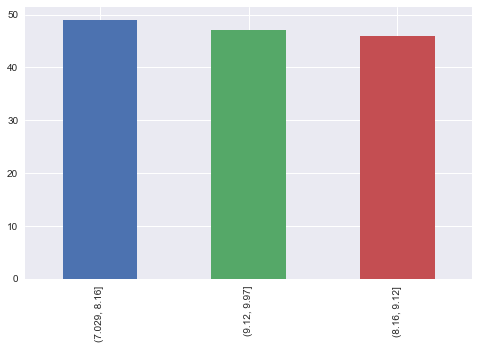

```python
df_corr['Price_Bin'] = pd.qcut(df_corr['price'],3)
df_corr.Price_Bin.value_counts().plot(kind='bar')
```

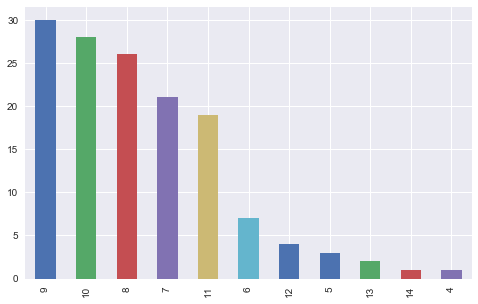

```python
df_eda.ing_count.value_counts().plot(kind='bar')
```

### *Price to Score relation* with log transformation

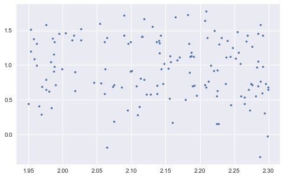

```python
#score to price relation
plt.plot(np.log(df_eda.price), np.log(target), '.')
```

There seems to be no correlation between **price** and the **score**

#### From pairplots, it appears like we have a linear relationship between total ingredient weight to the target variable

#### Lets apply log transformation to see if the relationship looks more evident or not

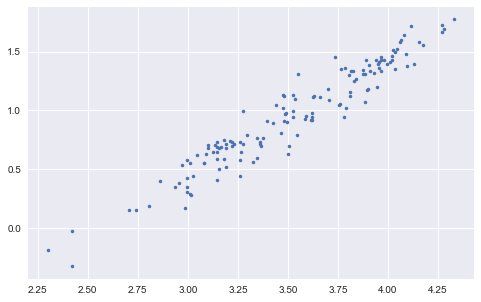

```python
plt.plot(np.log(df_eda.ing_weight), np.log(target), '.')
```

#### Voila!

it looks more like a **straight line relationship** between ing_weight and score. However, we can confirm it later by **using model OLS**.

Go to Top

### 3. Find Insignificant features using Statsmodel

We will use OLS fit to identify whether there is relationship between the predictors and the target variable and if there is a relationship, we can understand how strong is that relationship

```python
def stats_model(x,y):
    x = sm.add_constant(x)
    model = sm.OLS(y,x)
    result = model.fit()
    return result
```

```python
#stats model with price
result1 = stats_model(train_x['price'], train_y)
print(result1.summary())
```

```
                            OLS Regression Results
==============================================================================
Dep. Variable:                  score   R-squared:                       0.011
Model:                            OLS   Adj. R-squared:                  0.004
Method:                 Least Squares   F-statistic:                     1.550
Date:                Thu, 16 May 2019   Prob (F-statistic):              0.215
Time:                        00:35:42   Log-Likelihood:                -221.85
No. Observations:                 142   AIC:                             447.7
Df Residuals:                     140   BIC:                             453.6
Df Model:                           1
Covariance Type:            nonrobust
==============================================================================
                 coef    std err          t      P>|t|      [0.025      0.975]
------------------------------------------------------------------------------
const          3.9787      0.930      4.280      0.000       2.141       5.817
price         -0.1342      0.108     -1.245      0.215      -0.347       0.079
==============================================================================
Omnibus:                        8.531   Durbin-Watson:                   1.959
Prob(Omnibus):                  0.014   Jarque-Bera (JB):                8.132
Skew:                           0.528   Prob(JB):                       0.0172
Kurtosis:                       2.492   Cond. No.                         83.3
==============================================================================

Warnings:
[1] Standard Errors assume that the covariance matrix of the errors is correctly specified.
```

**Model fitted with only *price* predictor turned out to be a bad fit. *p-value* is insignificant. Hence we can say that there is no relationship between price and recipe score and hence we fail to reject the null hypothesis.**

```python
#stats model with ing_count
result2 = stats_model(train_x['ing_count'], train_y)
print(result2.summary())
```

```
                            OLS Regression Results
==============================================================================
Dep. Variable:                  score   R-squared:                       0.050
Model:                            OLS   Adj. R-squared:                  0.043
Method:                 Least Squares   F-statistic:                     7.303
Date:                Thu, 16 May 2019   Prob (F-statistic):            0.00774
Time:                        00:35:45   Log-Likelihood:                -219.02
No. Observations:                 142   AIC:                             442.0
Df Residuals:                     140   BIC:                             448.0
Df Model:                           1
Covariance Type:            nonrobust
==============================================================================
                 coef    std err          t      P>|t|      [0.025      0.975]
------------------------------------------------------------------------------
const          1.5241      0.492      3.099      0.002       0.552       2.496
ing_count      0.1466      0.054      2.702      0.008       0.039       0.254
==============================================================================
Omnibus:                        8.821   Durbin-Watson:                   1.991
Prob(Omnibus):                  0.012   Jarque-Bera (JB):                8.525
Skew:                           0.546   Prob(JB):                       0.0141
Kurtosis:                       2.501   Cond. No.                         47.2
==============================================================================

Warnings:
[1] Standard Errors assume that the covariance matrix of the errors is correctly specified.
```

*p-value* of ing_count predictor seems significant. However, this predictor alone could not explain the variance of the model. R-sqaured values is significantly low

```python
#stats model with ingredients_weight
result3 = stats_model(train_x['ing_weight'], train_y)
print(result3.summary())
```

```
                            OLS Regression Results
==============================================================================
Dep. Variable:                  score   R-squared:                       0.920
Model:                            OLS   Adj. R-squared:                  0.919
Method:                 Least Squares   F-statistic:                     1601.
Date:                Thu, 16 May 2019   Prob (F-statistic):           1.69e-78
Time:                        00:37:13   Log-Likelihood:                -43.688
No. Observations:                 142   AIC:                             91.38
Df Residuals:                     140   BIC:                             97.29
Df Model:                           1
Covariance Type:            nonrobust
==============================================================================
                 coef    std err          t      P>|t|      [0.025      0.975]
------------------------------------------------------------------------------
const          0.0715      0.074      0.963      0.337      -0.075       0.218
ing_weight     0.0750      0.002     40.007      0.000       0.071       0.079
==============================================================================
Omnibus:                        6.644   Durbin-Watson:                   2.165
Prob(Omnibus):                  0.036   Jarque-Bera (JB):                8.278
Skew:                           0.279   Prob(JB):                       0.0159
Kurtosis:                       4.043   Cond. No.                         106.
==============================================================================

Warnings:
[1] Standard Errors assume that the covariance matrix of the errors is correctly specified.
```

**As expected from exploratory data analysis, this predictor has explained highest proportion of variance with a significant p-value for a highest t-statistic. Estimated co-efficient for ing_weight also has very less Standard Error.**

```python
#stats model with ing_weight & ing_count
result4 = stats_model(train_x[['ing_weight','ing_count']], train_y)
#result4 = stats_model(train_x[['ing_weight','ing_count', 'price']], train_y)
print(result4.summary())
```

```
                            OLS Regression Results
==============================================================================
Dep. Variable:                  score   R-squared:                       0.926
Model:                            OLS   Adj. R-squared:                  0.925
Method:                 Least Squares   F-statistic:                     874.3
Date:                Thu, 16 May 2019   Prob (F-statistic):           1.83e-79
Time:                        00:37:16   Log-Likelihood:                -37.418
No. Observations:                 142   AIC:                             80.84
Df Residuals:                     139   BIC:                             89.70
Df Model:                           2
Covariance Type:            nonrobust
==============================================================================
                 coef    std err          t      P>|t|      [0.025      0.975]
------------------------------------------------------------------------------
const          0.5016      0.140      3.592      0.000       0.226       0.778
ing_weight     0.0772      0.002     40.683      0.000       0.073       0.081
ing_count     -0.0572      0.016     -3.583      0.000      -0.089      -0.026
==============================================================================
Omnibus:                        6.858   Durbin-Watson:                   2.084
Prob(Omnibus):                  0.032   Jarque-Bera (JB):                8.685
Skew:                           0.283   Prob(JB):                       0.0130
Kurtosis:                       4.071   Cond. No.                         213.
==============================================================================

Warnings:
[1] Standard Errors assume that the covariance matrix of the errors is correctly specified.
```

### Here, we can conclude that *ing_weight* and *ing_count* are statistically significant variables for predicting *score*

## 2. Subset Selection

Select the **most significat features** from the train and validation sets to perform machine learning

```python
#selecting only significat features from statsmodel
train_x_sub = train_x[['ing_weight', 'ing_count']] #train set
val_x_sub = val_x[['ing_weight','ing_count']] #validation set
```

Go to Top

# Part IV MACHINE LEARNING

## 1. Baseline Models

From the analysis so far and from the exploratory data analysis, this problem looks like a linear regression where we seems to have a **linear relationship** between predictor and target varaibles.  
Hence mostly **linear models would perform better**, however, we will fit other models too to see if they can outperform the linear regression in this setting.

### a. Initialize Models

```python
#linear models
lr = LinearRegression()
rcv = RidgeCV() #For L2 regularization
#ensemble
gb = GradientBoostingRegressor() #boositing
rf = RandomForestRegressor() #bagging
#xgb
xgb = XGBRegressor() #XGB
models = [xgb, gb, rf, lr, rcv]
```

```python
#This function will return the calculated r2 score and rmse for given predictions and actuals
def reg_metrics(preds, actuals):
    rmse = np.sqrt(mean_squared_error(preds, actuals))
    r2 = r2_score(preds, actuals)
    return rmse, r2
```

### Elavuation Metric:

I am evaluating the models' performance based on the **Root Mean Squared Error**. This metric can show the bigger deviations in the error clearly.  
**R-Squared** can also help us understand the proportion of variance explained. However, if we add more variables, R-sqaured keeps increasing. Hence, we will keep this metric as a **side-reference** to understand the **goodness** of fit.

We will first compare the base models based on their Validation set RSMEs.

```python
print(train_x_sub.shape)
Model_columns = ['Model Name', 'Train RMSE', 'Val RMSE']
Model_compare = pd.DataFrame(columns=Model_columns)
row_index = 0

for alg in models:
    Model_name = alg.__class__.__name__
    Model_compare.loc[row_index, 'Model Name'] = Model_name
    alg.fit(train_x_sub, train_y)
    tr_preds = alg.predict(train_x_sub)
    tr_rmse = np.sqrt(mean_squared_error(tr_preds, train_y))

    val_preds = alg.predict(val_x_sub)
    val_rmse = np.sqrt(mean_squared_error(val_preds, val_y))

    Model_compare.loc[row_index, 'Train RMSE'] =tr_rmse
    Model_compare.loc[row_index, 'Val RMSE'] =val_rmse

    row_index+=1
Model_compare.sort_values(by = ['Val RMSE'], ascending = True, inplace=True)
Model_compare
```

```
(142, 2)
```

|  | Model Name | Train RMSE | Val RMSE |
| --- | --- | --- | --- |
| 4 | RidgeCV | 0.31493 | 0.334949 |
| 3 | LinearRegression | 0.314921 | 0.335343 |
| 2 | RandomForestRegressor | 0.175328 | 0.359518 |
| 0 | XGBRegressor | 0.196262 | 0.367683 |
| 1 | GradientBoostingRegressor | 0.164371 | 0.388762 |

### Inferences:

Clearly **linear models** performed consistently on both train and validation sets with low variance.  
However, the non-linear algorithms such as **ensemble methods** had a huge variance on training data vs unseen data.

Both **Linear Regression** and **RidgeCV** performed almost similar. Hence lets take these algorithms to **optimize and reduce** RMSE further.  
We can also consider **XGBoost Regressor** to try parameter tuning and see if it can perform any better.  
However, this is a clear linear regression setting and mostly it would be linear models that would perform better. **Lets explore.**

## 2. Model Optimization

### a. KFold CrossValidation

**Train LinearRegression and RidgeCV using KFold CrossValidation**

```python
n=15 #we are splitting the data in to 3 sets.
kf = KFold(n, False, random_state=32)
data_x = np.array(train_x_sub)
data_y = np.array(train_y)
```

```python
lr_kf = LinearRegression()
rcv_kf = RidgeCV()
sum_rmse_lr, sum_r2_lr, sum_rmse_rcv, sum_r2_rcv = (0.0, 0.0, 0.0, 0.0)

for train, valid in kf.split(data_x):
    #Create new train set and validation set from 'train_x and train_y' dataset.
    new_train_x, new_train_y = (pd.DataFrame(data_x[train]),pd.DataFrame(data_y[train]))
    valid_set_x, valid_set_y = (pd.DataFrame(data_x[valid]),pd.DataFrame(data_y[valid]))

    lr_kf.fit(new_train_x, new_train_y) #fit the linear regression model on new train set
    preds_kf_lr = lr_kf.predict(valid_set_x)
    rcv_kf.fit(new_train_x, new_train_y) #fit ridgeCV model on new train set
    preds_kf_rcv = rcv_kf.predict(valid_set_x)

    rmse_kf_lr, r2_kf_lr = reg_metrics(valid_set_y, preds_kf_lr)
    rmse_kf_rcv, r2_kf_rcv = reg_metrics(valid_set_y, preds_kf_rcv)

    sum_rmse_lr += rmse_kf_lr
    sum_r2_lr += r2_kf_lr
    sum_rmse_rcv += rmse_kf_rcv
    sum_r2_rcv += r2_kf_rcv

mean_rmse_lr = sum_rmse_lr/n
mean_r2_lr = sum_r2_lr/n
mean_rmse_rcv = sum_rmse_rcv/n
mean_r2_rcv = sum_r2_rcv/n

print('LR: rmse {} | r2  {} '.format(mean_rmse_lr,mean_r2_lr))
print('RCV: rmse {} | r2  {} '.format(mean_rmse_rcv,mean_r2_rcv))
```

```
LR: rmse 0.31050529031997964 | r2  0.8887289364115819
RCV: rmse 0.3104529738338837 | r2  0.8888609782187576
```

### b. Parameter Tuning - Using GridSearchCV

**Tuning XGBRegressor**

```python
def gridsearch(param_grid, model, train_x, train_y):
    gs = GridSearchCV(model, param_grid = param_grid, scoring = 'neg_mean_squared_error', cv =10 )
    gs.fit(train_x, train_y)
    return gs.best_estimator_
```

```python
#define list of parameters for the the XGBoostingRegressor
param_grid_xgb = {"n_estimators" : [520, 0, 100, 120],
           "max_depth" : [1, 3], "learning_rate" : [0.01, 0.05, 0.1]}
xgb_best_est = gridsearch(param_grid_xgb, xgb, train_x_sub, train_y)
xgb_best_est
```

```
XGBRegressor(base_score=0.5, booster='gbtree', colsample_bylevel=1,
       colsample_bytree=1, gamma=0, learning_rate=0.1, max_delta_step=0,
       max_depth=1, min_child_weight=1, missing=None, n_estimators=120,
       n_jobs=1, nthread=None, objective='reg:linear', random_state=0,
       reg_alpha=0, reg_lambda=1, scale_pos_weight=1, seed=None,
       silent=True, subsample=1)
```

### Top Contenders

**1. lr_kf**  
**2. rcv_kf**  
**3. xgb_best_est**

## 3. Prediction on Validation Set

### a. Predict using top Models

```python
xgb_val_preds = xgb_best_est.predict(val_x_sub)
lr_kf_val_preds = lr_kf.predict(val_x_sub)
rcv_kf_val_preds = rcv_kf.predict(val_x_sub)
```

### b. Evaluate Validations Set Results

```python
lr_val_rmse, lr_val_r2 = reg_metrics(lr_kf_val_preds, val_y)
print('LR Val RMSE:{} | R2 Score:{}'.format(lr_val_rmse, lr_val_r2))

rcv_val_rmse, rcv_val_r2 = reg_metrics(rcv_kf_val_preds, val_y)
print('RCV Val RMSE:{} | R2 Score:{}'.format(rcv_val_rmse, rcv_val_r2))

xgb_val_rmse, xgb_val_r2 = reg_metrics(xgb_val_preds, val_y)
print('XGB Val RMSE:{} | R2 Score:{}'.format(xgb_val_rmse, xgb_val_r2))
```

```
LR Val RMSE:0.3356335483203772 | R2 Score:0.9036043903889357
RCV Val RMSE:0.33526700879917903 | R2 Score:0.9036823188591259
XGB Val RMSE:0.3299364321256678 | R2 Score:0.9041479447694263
```

### c. Try adding 'price' to the dataset

The idea is to check if adding price will have any improvement on the non-parametric models, here XGBregressor. Since price introduces non-linearity, we can check if non-parametric model can learn better.

```python
#train_set with price
train_x_pr = train_x[['ing_weight', 'ing_count', 'price']]
train_y_pr = train_y
#validation set with price
val_x_pr = val_x[['ing_weight','ing_count', 'price']]
```

```python
param_grid_xgb_pr = {"n_estimators" : [520, 100, 120, 800],
           "max_depth" : [1, 3, 5], "learning_rate" : [0.01, 0.05, 0.1]}
xgb_pr_best_est = gridsearch(param_grid_xgb_pr, xgb, train_x_pr, train_y_pr)
```

```python
preds_pr = xgb_pr_best_est.predict(val_x_pr)
rmse_xgbpr, r2_xgbpr = reg_metrics(preds_pr, val_y)
print('XGB with Price Val RMSE:{} | R2 Score:{}'.format(rmse_xgbpr, r2_xgbpr))
```

```
XGB with Price Val RMSE:0.3293591015865916 | R2 Score:0.9046967094805802
```

**There is a very slight improvement in XGB model by adding price. A good observation to make a note of. However, we can explore this in further phases of this project. For now, given time constraints we will continue with the statistically significant columns only.**

Go to Top

## 4. Final Model Selection

### RidgeCV

Though XGBoost has fared slightly better than linear-models, we can rely on linear models in this setting as they tend to have lesser variance than XGBoost and other non-parametric models considering that we have less number of records.

Hence, we will select **RidgeCV** as our **final model** and tune it futher to improve the performance.

We will try to optimize model performance by few techniques.  
Firstly, our data is **not scaled yet**. During exploratory data analysis, we have noticed that log transformation made the relationship between *ingredient_weight* and *score* look more linear.

### a. log transformation

We will try *log transforming* our data to see if that can reduce the **RMSE** further.

```python
#new train set
train_x_log = pd.DataFrame(np.log(train_x[['ing_weight', 'ing_count']]))
train_y_log = np.log(train_y)
#new validation set
val_x_log = pd.DataFrame(np.log(val_x[['ing_weight','ing_count']]))
```

```python
rcv_final = RidgeCV()
rcv_final.fit(train_x_log, train_y_log)
val_preds_log = rcv_final.predict(val_x_log)
val_preds = np.exp(val_preds_log) #convert log predictions to real numerics
```

```python
val_rmse, val_r2 = reg_metrics(val_preds, val_y)
print('Ridge CV RMSE:{}  |  R2:{}'.format(val_rmse, val_r2))
```

```
Ridge CV RMSE:0.32765514120261996  |  R2:0.907162951838385
```

This **RMSE is reduced** compared to non-log transformed data. Hence, **log** transformation of data has **helped** us improve the model performance

### FInal Validation Set RMSE stands at: *<font color = blue> 0.32765* with *~90%* of the variance explained

**<font color = red>Note:</font> We can further compare the predicted values with the real ratings to see how many good recipes are being rated <font color = blue>*high but NOT low*</font> and how many low rated recipes are being rated <font color = blue>*low but NOT high*</font>. That can be a better <font color = 'green'>business metric</font> to evaluate this model.**

## 6. Test Set Predictions

In this section, we will use our final RidgeCV model to predict the **unkown** scores for our new recipes.

```python
test_x_log = pd.DataFrame(np.log(test[['ing_weight','ing_count']]))
```

```python
test_preds_log = rcv_final.predict(test_x_log)
test_preds = np.exp(test_preds_log)
```

```python
test['score'] = test_preds
test.head()
```

|  | price | ing_count | recipe_word_count | ing_weight | score |
| --- | --- | --- | --- | --- | --- |
| 29 | 8.18 | 7 | 8 | 30.00 | 2.380691 |
| 36 | 9.68 | 8 | 5 | 49.00 | 3.801304 |
| 44 | 8.89 | 7 | 6 | 46.75 | 3.700155 |
| 66 | 8.73 | 7 | 6 | 31.50 | 2.499002 |
| 106 | 7.07 | 9 | 7 | 36.35 | 2.776145 |

```python
#export predicted test_set with scores
test_predicted = test.copy()
test_predicted['recipe_code'] = test_recipes
test_predicted.to_csv(f'{PATH}test_predicted.csv')
```

```python
import time
timestr = time.strftime("%Y%m%d_%H%M%S")
print(timestr)
```

```
20190516_115909
```

```python
timestr2 = time.strftime("%H:%M:%S")
st = "predictions posted at "+timestr2
st
```

```
'predictions posted at 12:18:39'
```

```python
print('{}test_predicted_{}.csv'.format(PATH,timestr))
```

```
C:/Users/kpunyakoti/Desktop/Future/HelloFresh/test_predicted_20190516_115909.csv
```

```python
atings = pd.read_sql_query("select recipe_code from recipe_ratings where score ='NaN'", connection)
```

```python
atings.shape
```

```
(43, 1)
```

## 7. Productionizing the model

We will us **pickle** module to export our best performing **final model**

```python
import pickle
# Dump the trained RidgeCV with Pickle
rcv_final_pkl_filename = 'rcv_final_20190516.pkl'
# Open the file to save as pkl file
rcv_final_pkl = open(rcv_final_pkl_filename, 'wb')
pickle.dump(rcv_final, rcv_final_pkl)
# Close the pickle instances
rcv_final_pkl.close()
```

### Next Steps:

#### 1. We will use this pkl file to predict the new recipe scores in production environment.

#### 2. We will deploy this model on flask using a separate python script.

#### 3. Based on the performance and with more data, we can retrain our models and select a best performing one.

### Final Note:

There could be **many** other possible and **innvotive ways** to make these models better.  
With more data and much more **business understanding**, we can come up with many other **innovative features** or mechanisms to predict the **score better**.

# Thank You

Go to Top

## *References*

ML modelling, project flow, Tips and Best Practices -  
**Hands on Machine Learning using Scikit Learn and Tensorflow** book by **Aurelien Geron**.  
**An Introduction to Statistical Learning** and  
**The lessons learnt from personal failed attempts at my work**

Jupyter notebook editing tips - https://medium.com/ibm-data-science-experience/markdown-for-jupyter-notebooks-cheatsheet-386c05aeebed

Project Insights - https://rstudio-pubs-static.s3.amazonaws.com/296592_29cd90970f7f4e18958a215416803927.html